# testOTM Vignette

Peng Xu

18 November 2019

`testOTM` is a package that computes multivariate ranks and quantiles defined through the theory of optimal transports. It also provides several applications of these statistics, most notably the two-sample multivariate goodness-of-fit testing.

## Introduction

As mentioned, the core of the definitions used by this package is optimal transport: given Borel (probabiliy) measures $\mu$ (source) and $\nu$ (target), whose convex compact supports are $\mathcal{X}\subset\mathbb{R}^d$ and $\mathcal{Y}\subset\mathbb{R}^d$ respectively, a map $T\colon\mathcal{X}\to\mathcal{Y}$ attaining
$$\inf_{T: T\mathbin{\#}\mu=\nu}\int_{\mathcal{S}}\left\lVert s-T(s)\right\rVert_2^2\,d\mu(s)$$
is called the ($L_2$-) optimal transport map, where the notation $T\mathbin{\#}\mu=\nu$ means $\mu(T^{-1}(B))=\nu(B)$ for all Borel $B\subset\mathcal{Y}$. When $\nu$ is univariate and $\mu\sim U[0,1]$, the map $T$ provides an analogues of the one-dimensional quantile function of $\nu$. Thus, by substituting $\mu\sim U[0,1]^d$ when $\nu$ is of dimension $d$, we are able to generalized the notions of quantiles and ranks, see (Ghosal and Sen 2019; Chernozhukov et al. 2017) for more detail.

In application, we do not usually know the target measure $\nu$, but rather have a finite sample $\{X_i\}_{i=1}^n\sim\nu$. We thus replace the unknown $\nu$ by its empirical distribution $\hat{\nu}_n$, which satisfies
$$\hat{\nu}_n(B)=\frac{1}{n}\sum_{i=1}^n\delta_{X_i}(B)$$
for all Borel $B\subset\mathcal{Y}$. Accordingly, we define the empirical quantile function $\hat{Q}_n$ to be the solution of the optimal transport problem when $\hat{\nu}_n$ is used. An important result, known as Brenier-McCann’s Theorem (Brenier 1991; McCann 1995), states that there exists a piecewise affine function $\hat{\psi}_n$ such that $\hat{Q}_n=\nabla\hat{\psi}_n$. Through some justifications from the convex optimization theory, the empirical rank function can be defined as
$$\hat{R}_n(\mathbf{x})=\operatorname*{arg\,min}_{\mathbf{y}\in\mathcal{Y}}\{\mathbf{x}^\top\mathbf{y}-\hat{\psi}_n(\mathbf{y})\},$$
and it can be computed through linear programming.

## Visualizing the Transport Map, Rank, and Quantiles

When the source measure $\mu$ is continuous and target measure $\nu$ is discrete, the optimal transport problem is said to be semi-discrete. The solution in this case turns out to have a nice geomtric interpretation: it is a partition of $\mathcal{X}$ by convex polytopes, where each polytope corresponds to one of the $X_i$’s (known as the seeds in this context). This partition is called the power diagram or the Laguerre diagram (and is in fact a generalization of the Voronoi diagram), see (Aurenhammer 1987) for more information.

Efficient algorithms for solving the semi-discrete optimal transport problem in 2D/3D have been proposed in (Lévy and Schwindt 2018), and are implemented in the [`Geogram`](http://alice.loria.fr/software/geogram/doc/html/index.html) library. `testOTM` provides a wrapper to `Geogram` to solve the specific problems when $\mu$ equals $U[0,1]^2$ or $U[0,1]^3$.

In the following example, we demonstrate how to compute and visualize the optimal transport map from $U[0,1]^2$ to a bivariate Gaussian sample $\{X_i\}_{i=1}^{20}$:

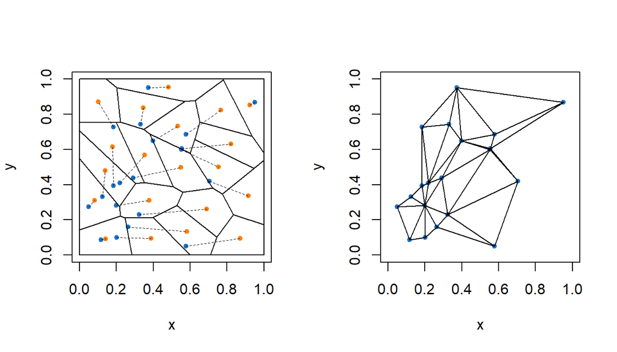

```r
# generate bivariate normal sample
p = 2
n = 20
Sigma = matrix(c(3, 1, 1, 3), p, p)
eS = eigen(Sigma, symmetric = TRUE)
X = t(eS$vectors %*% diag(sqrt(pmax(eS$values, 0)), p) %*% matrix(rnorm(p * n), p))

# compute the optimal transport map from U[0, 1]^2 to X
# notice that X will be automatically scaled into [0, 1] range
# tos is an abbreviation for Transport Optimal Semi-discret
X.OTM = tos.fit(X)

# plot the restricted Voronoi diagram and the restricted Delaunay triangulation
par(mfrow = c(1, 2))
plot(X.OTM, which = "Both", draw.center = T, draw.map = T)
```

The two plots being produced are the restricted Voronoi diagram (RVD) and the restricted Delaunay triangulation (RDT). RVD is the partition we mentioned above, each polygon (cell) corresponds to one datum (blue point), and any point within that cell will be transported to the datum by the optimal map. The orange points are the centroids of the cells, and by setting `draw.map = T`, dashed lines will be draw between the centroids and the data to indicate which cell corresponds to which data point. The RDT on the other hand is the dual of the RVD and has many computational applications, see for example (Cheng, Dey, and Shewchuk 2013; Toth, O’Rourke, and Goodman 2017) for more information.

Now with a fitted `tos.2d` object available, we can use it to compute the 2D empirical ranks and quantiles. The following snippet shows how to do so for some arbitrary points $\{Y_i\}_{i=1}^{5}$:

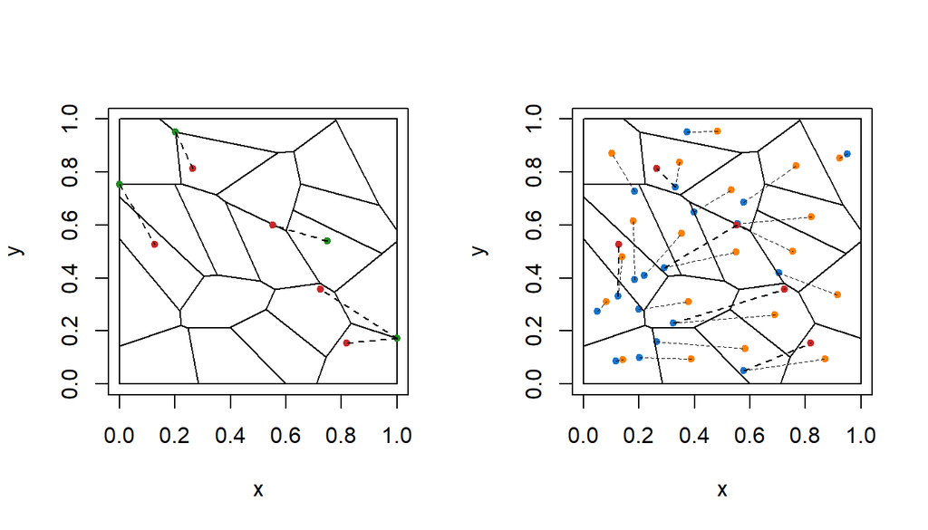

```r
# choose some arbitrary points
Y = matrix(c(3.2, -0.9,
             -1.2, 1.8,
             4.1, -2.1,
             -2.5, 0.1,
             0, 0), ncol = 2, byrow = T)
Y[5, ] = X[1, ] # take one point from data
R = tos.rank(X.OTM, Y) # compute ranks
Q = tos.quantile(X.OTM, Y) # compute quantiles

# to visualize ranks and quantiles, we first apply the scaling of X on Y
Y = scale(Y, X.OTM$Location, X.OTM$Scale)
Y = Y * diff(range(X.OTM$Data)) + min(X.OTM$Data)

# plot ranks
par(mfrow = c(1, 2))
plot(X.OTM, which = "RVD", draw.center = F, draw.map = F, draw.data = F)
points(Y, col = "firebrick3", pch = 20)
points(R$Rank, col = "forestgreen", pch = 20)
segments(R$Rank[, 1], R$Rank[, 2], Y[, 1], Y[, 2], lty = 2)

# plot quantiles
plot(X.OTM, which = "RVD", draw.center = T, draw.map = T, draw.data = T)
points(Y, col = "firebrick3", pch = 20)
segments(Q$Quantiles[, 1], Q$Quantiles[, 2], Y[, 1], Y[, 2], lty = 2)
```

The left plot shows the query points (red) and their corresponding ranks (green). By the nature of their definition, ranks are always vertices of some cells in the RVD, except when the query is a data point $X_i$, in which case $\hat{R}_n$ is not uniquely defined and can be any point in the closure of the cell corresponds to $X_i$. By default, `tos.rank` will sample a point uniformly from that cell.

The right plot meanwhile shows the quantiles of the query points. As pointed out earlier, the query points will be map to the data points that correspond to the cells they are in.

The similar visualization procedure can be done for 3D data sets as well. `testOTM` supports both interactive (via package `rgl`) and non-interactive (via package `plot3D`) plotting of the RVD and the RDT. The following example shows the optimal transport map between $U[0,1]^3$ and a trivariate Gaussian sample:

```r
# generate trivariate normal data
p = 3
n = 10
Sigma = matrix(c(2, 1, 1, 1, 2, 1, 1, 1, 2), p, p)
eS = eigen(Sigma, symmetric = TRUE)
X = t(eS$vectors %*% diag(sqrt(pmax(eS$values, 0)), p) %*% matrix(rnorm(p * n), p))

# compute the optimal transport map from U[0, 1]^3 to the data
X.OTM = tos.fit(X)
```

```
#> o-[OTM         ] In RVD (centroids)...
#> o-[RVD         ] Elapsed time: 0 s
```

```r
# plot the restricted Voronoi diagram and the restricted Delaunay triangulation
plot(X.OTM, which = "RVD", draw.center = T, draw.map = T)

# embed the plot into the current document
rglwidget(elementId = "plot3drgl", height = 600, width = 600)
```

[interactive chart not shown]

Back to Top

## Non-parametric Testing

With multivariate ranks and quantiles defined, we can use them to construct non-parametric test statistics for various uses. One such application is the goodness-of-fit test: given independent $\{X_i\}_{i=1}^n\sim\nu_X$ and $\{Y_i\}_{i=1}^m\sim\nu_Y$, we want to test
$$H_0\colon\nu_X=\nu_Y\qquad\text{versus}\qquad H_1\colon\nu_X\neq\nu_Y.$$
Function `tos.gof.test` implements the statistic (for 2D and 3D) proposed in (Ghosal and Sen 2019) for this test:
$$T_{X,Y}=\int_{[0,1]^d}\left\lVert\hat{R}_{X,Y}(\hat{Q}_{X}(u))-\hat{R}_{X,Y}(\hat{Q}_{Y}(u))\right\rVert_2^2\,d\mu(u),$$
where $\mu=U[0,1]^d$. Under the null hypothesis $T_{X,Y}$ is expected to be small so we reject $H_0$ if $T_{X,Y}$ exceeds certain critical value. However, since we do not yet have the analytical form of the null distribution, we compute the $p$-value through permutations instead. In addition, the integral in the definition of $T_{X,Y}$ is evaluated through quasi-Monte Carlo, and by default we use a Sobol sequence of length $10000$.

The following example showcases a goodness-of-fit test with $H_0$ false. For simplicity we set the number of permutations to $100$, in practice this parameter is usually set to $500$, $1000$, or $1500$.

```r
# simulate data, H_0 false
p = 2
n = 100
Sigma1 = matrix(c(3, 1, 1, 3), p, p)
eS = eigen(Sigma1, symmetric = TRUE)
X = t(eS$vectors %*% diag(sqrt(pmax(eS$values, 0)), p) %*% matrix(rnorm(p * n), p))
Sigma2 = matrix(c(5, 3, 3, 2), p, p)
eS = eigen(Sigma2, symmetric = TRUE)
Y = t(eS$vectors %*% diag(sqrt(pmax(eS$values, 0)), p) %*% matrix(rnorm(p * n), p))

# two sample goodness-of-fit test
GoF = tos.gof.test(X, Y, n.perm = 100)
GoF
```

```
#> $perm.stats
#>   [1] 0.05547294 0.01362790 0.02020353 0.02025701 0.02222902 0.01547936
#>   [7] 0.01775848 0.01510168 0.02076719 0.01271096 0.02889391 0.01589894
#>  [13] 0.01733697 0.02083321 0.01310197 0.01815264 0.01476966 0.01402921
#>  [19] 0.04092426 0.01297677 0.02086594 0.01922223 0.01627245 0.01778115
#>  [25] 0.01559354 0.02069145 0.01589480 0.01770116 0.01783689 0.01821656
#>  [31] 0.01455673 0.02269634 0.01937998 0.01361806 0.01664510 0.01908505
#>  [37] 0.01742552 0.02645806 0.02266787 0.01691875 0.01683172 0.01768728
#>  [43] 0.01511479 0.01708146 0.01722143 0.01275648 0.01964849 0.02114601
#>  [49] 0.02529509 0.01726285 0.01492604 0.01775032 0.01606573 0.01908499
#>  [55] 0.01877251 0.02560740 0.01515603 0.01745057 0.01483496 0.01969811
#>  [61] 0.01544080 0.01825925 0.02120513 0.01411049 0.01752653 0.01612723
#>  [67] 0.01568712 0.02220282 0.01356071 0.01963889 0.01731658 0.01644406
#>  [73] 0.02146766 0.01445971 0.02676911 0.01803858 0.02336171 0.03397531
#>  [79] 0.02224157 0.02315803 0.01806431 0.01927216 0.02286131 0.01920470
#>  [85] 0.03045460 0.02080260 0.01981565 0.01389055 0.02064275 0.01999544
#>  [91] 0.01805560 0.01490642 0.04178384 0.01436522 0.01584841 0.01928399
#>  [97] 0.01698221 0.01437074 0.02017172 0.01729559 0.02056135
#>
#> $p.value
#> [1] 0.00990099
```

Back to Top

Another useful application of the multivariate ranks and quantiles in non-parametric testing is the test of independence: given samples $\{Z_i=(X_i, Y_i)\}\sim\nu$, where $X_i\sim\nu_X$ and $Y_i\sim\nu_Y$, we’d like to test
$$H_0\colon\nu=\nu_X\otimes\nu_Y\qquad\text{versus}\qquad H_1\colon\nu\neq\nu_X\otimes\nu_Y.$$
A test statistic for this is presented in (Ghosal and Sen 2019) and reduced to the following when both $X_i$ and $Y_i$ are univariate:
$$T_n=\frac{1}{n}\sum_{i=1}^n\left\lVert\hat{R}_{Z}(\hat{Q}_{Z}(u))-\tilde{R}_{Z}(\hat{Q}_{Z}(u))\right\rVert_2^2,$$
where $\tilde{R}_{Z}=(\hat{R}_{X},\hat{R}_{Y})$ is simply the joining of the usual 1D ranks of $X$ and $Y$. The following snippet showcases how to perform this test with `tos.dep.test`:

```r
# simulate data, H_0 false
p = 2
n = 100
Sigma = matrix(c(5, 3, 3, 2), p, p)
eS = eigen(Sigma, symmetric = TRUE)
Z = t(eS$vectors %*% diag(sqrt(pmax(eS$values, 0)), p) %*% matrix(rnorm(p * n), p))
X = Z[, 1]
Y = Z[, 2]

# test of independence
Dep = tos.dep.test(X, Y, n.perm = 100)
Dep
```

```
#> $perm.stats
#>   [1] 0.073505775 0.006518720 0.004143096 0.005541443 0.005001417 0.006595635
#>   [7] 0.005252833 0.006505574 0.003433359 0.004327010 0.004873735 0.005019515
#>  [13] 0.004789883 0.006012297 0.004064832 0.003968829 0.005364283 0.005100733
#>  [19] 0.005533224 0.007205579 0.004206188 0.004333355 0.005751853 0.004721478
#>  [25] 0.004132254 0.006250693 0.003724183 0.004856850 0.005691049 0.005835331
#>  [31] 0.004829793 0.005157377 0.005144305 0.006197362 0.006152218 0.006337448
#>  [37] 0.004229691 0.004489420 0.005762586 0.004583222 0.006165942 0.005937769
#>  [43] 0.004106408 0.006838442 0.004435239 0.006610882 0.005697316 0.004319662
#>  [49] 0.005161137 0.005551486 0.004602594 0.008249558 0.005559091 0.004151665
#>  [55] 0.004118469 0.004962297 0.004925248 0.004853449 0.004586046 0.006150044
#>  [61] 0.004990701 0.005853972 0.003831541 0.005185757 0.005071440 0.006480297
#>  [67] 0.004250496 0.004507833 0.004689384 0.005721124 0.005373306 0.005295352
#>  [73] 0.004355905 0.004242256 0.004017391 0.003833847 0.007453587 0.004522687
#>  [79] 0.007252121 0.004603467 0.004891666 0.005331738 0.004680589 0.005663563
#>  [85] 0.008634855 0.004519173 0.005219668 0.003815728 0.006149609 0.005723391
#>  [91] 0.005627175 0.004884437 0.005521158 0.005418946 0.006267264 0.004347151
#>  [97] 0.003461499 0.004890923 0.005063414 0.004540293 0.004248092
#>
#> $p.value
#> [1] 0.00990099
```

Back to Top

## Statistical Depth

The statistical depth is a measurement of the center-outward ordering of points in the support of a distribution, and it can be used to generalize some univariate notions, such as the median, to multivariate. Following suggestion of (Chernozhukov et al. 2017), given samples $\{X_i\}_{i=1}^n\sim\nu$ in $\mathbb{R}^d$, we compute the depth as
$$\hat{D}_n(\mathbf{x})=\frac{1}{2}-\left\lVert\hat{R}_{n}(\mathbf{x})-\frac{1}{2}\mathbf{1}_d\right\rVert_\infty.$$
The following example shows the sample depth of the banana-shaped data presented in (Chernozhukov et al. 2017):

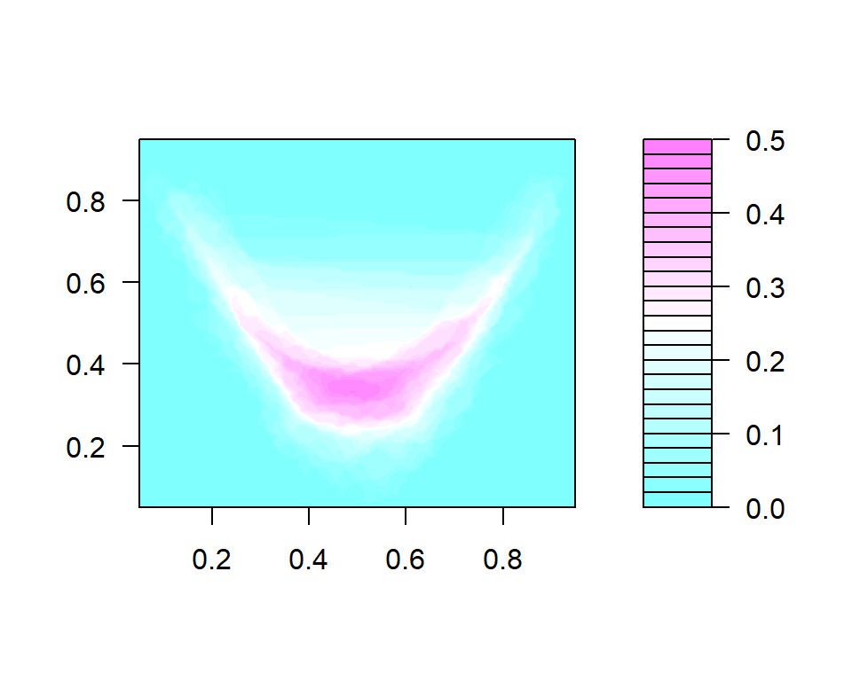

```r
# simulate banana-shaped data
n = 1000
x = runif(n, -1, 1)
phi = runif(n, 0, 2 * pi)
z = runif(n, 0, 1)
r = 0.2 * z * (1 + (1 - abs(x)) / 2)
X = cbind(x + r * cos(phi), x^2 + r * sin(phi))

# fit a transport map
X.OTM = tos.fit(X)

# set a grid to evaluate the depth, so that we can plot them
k = 100
q = seq(0.05, 0.95, length.out = k)
Q = as.matrix(expand.grid(q, q))

# compute depth, then plot its heatmap
D = tos.depth(X.OTM, Q, scale = F)
filled.contour(q, q, matrix(D, k, k), color.palette = function(n) cm.colors(n))
```

Back to Top

## Reference

Aurenhammer, F. 1987. “Power Diagrams: Properties, Algorithms and Applications.” *SIAM Journal on Computing* 16 (1): 78–96. https://doi.org/10.1137/0216006.

Brenier, Yann. 1991. “Polar Factorization and Monotone Rearrangement of Vector-Valued Functions.” *Communications on Pure and Applied Mathematics* 44 (4): 375–417. https://doi.org/10.1002/cpa.3160440402.

Cheng, Siu-Wing, Tamal Krishna Dey, and Jonathan Richard Shewchuk. 2013. *Delaunay Mesh Generation*. Chapman; Hall/CRC.

Chernozhukov, Victor, Alfred Galichon, Marc Hallin, and Marc Henry. 2017. “Monge–Kantorovich Depth, Quantiles, Ranks and Signs.” *The Annals of Statistics* 45 (1): 223–56. https://doi.org/10.1214/16-AOS1450.

Ghosal, Promit, and Bodhisattva Sen. 2019. “Multivariate Ranks and Quantiles Using Optimal Transportation and Applications to Goodness-of-Fit Testing.” http://arxiv.org/abs/1905.05340.

Lévy, Bruno, and Erica L. Schwindt. 2018. “Notions of Optimal Transport Theory and How to Implement Them on a Computer.” *Computers & Graphics* 72: 135–48. https://doi.org/10.1016/j.cag.2018.01.009.

McCann, Robert J. 1995. “Existence and Uniqueness of Monotone Measure-Preserving Maps.” *Duke Math. J.* 80 (2): 309–23. https://doi.org/10.1215/S0012-7094-95-08013-2.

Toth, Csaba D., Joseph O’Rourke, and Jacob E. Goodman, eds. 2017. *Handbook of Discrete and Computational Geometry*. 3rd ed. Chapman; Hall/CRC.